# Difference-in-difference

Nic Rivers

11/7/2019

## Introduction

This class covers difference in difference and panel data. In our lab today, we will look at an example relating to the minimum wage. Economists have long been interested in the minimum wage. Early (theoretical) assessments assumed that raising the minimum wage would deter employment. However, the [first empirical evaluation](https://www.nber.org/papers/w4509), by Card and Kreuger, surprised economists by finding that higher minimum wages *increased* employment. In this lab, we will look at minimum wages in Canada, to try to determine whether they have an impact on employment rates. We will focus especially on teen workers, since these workers are most likely to earn the minimum wage.

Our main research question aims to test whether changes in the minimum wage have an impact on teen employment rates in Canada.

## Data

I have assembled data for this lab from two sources. First, data on the minimum wage comes from [Employment and Social Development Canada](https://open.canada.ca/data/en/dataset/390ee890-59bb-4f34-a37c-9732781ef8a0). This data set shows how the minimum wage has evolved in each province. Second, we will use data on employment rates from [Statistics Canada](https://www150.statcan.gc.ca/t1/tbl1/en/tv.action?pid=1410028701). You can find the [full data set](https://raw.githubusercontent.com/nicrivers/uo_api_6319/master/minwage_data.csv) on the course website. If you are interested, I have also posted [the code](https://raw.githubusercontent.com/nicrivers/uo_api_6319/master/minwage_data.R) that I used to assemble the data from the original sources on the course website.

## Exploratory data analysis

Let’s take an initial look at the data to see what we’re working with. First, let’s plot the relationship between the minimum wage and the teen employment rate. We’ll try using a cross-sectional plot first, with one separate graph for each decade.

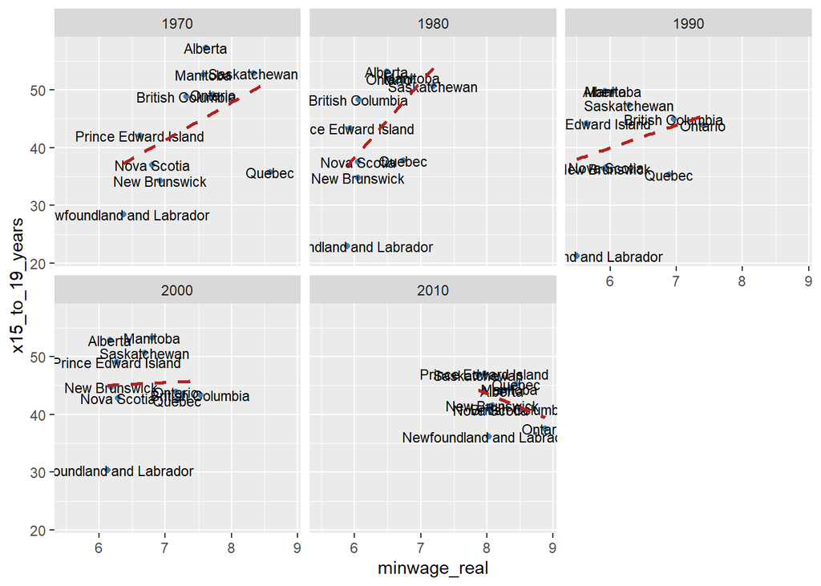

```r
library(tidyverse)
dat <- read_csv("minwage_data.csv")

# First create the "real" minimum wage
dat$minwage_real <- dat$minimum_wage / dat$cpi * 100

dat_decades <- dat %>%
  mutate(decade = year - year %% 10) %>%
  group_by(geo, sex, decade) %>%
  summarise_all(mean) %>%
  filter(sex == "Both sexes")

ggplot(dat_decades, aes(x=minwage_real, y=x15_to_19_years)) +
  geom_point(colour="steelblue") +
  geom_text(aes(label=geo), size=3) +
  geom_smooth(method="lm", se=F, linetype="dashed", colour="firebrick") +
  facet_wrap(~decade)
```

It’s hard to see a clear pattern in the cross-sectional data. Indeed, the general relationship between the minimum wage and the teen unemployment rate seems to flip over time. And, as we know, these relationships don’t likely reflect a cause-and-effect relationship because of the potential for confounders and even reverse causality.

Let’s look at the data another way – by comparing the minimum wage and the teen unemployment rate over time.

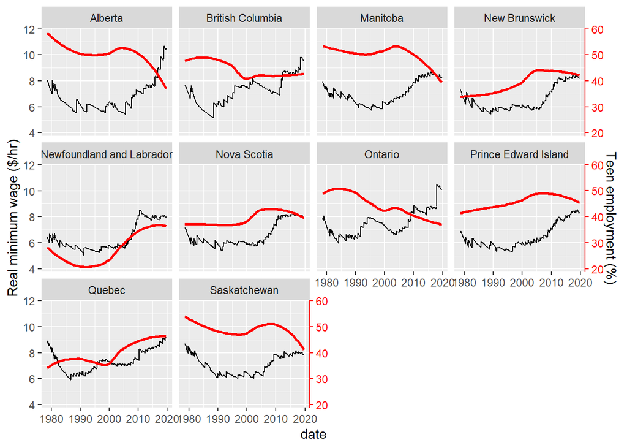

```r
dat$date <- as.Date(paste(dat$year, dat$month, "01", sep="-"))

ggplot(dat %>% filter(sex == "Both sexes"), aes(x=date, y=minwage_real)) +
  geom_line() +
  # second line on same scale
  geom_smooth(aes(y=x15_to_19_years/5), colour="red", se=F) +
  scale_y_continuous(name="Real minimum wage ($/hr)", sec.axis = sec_axis(~ . *5, name = "Teen employment (%)")) +
  facet_wrap(~geo) +
  theme( axis.line.y.right = element_line(color = "red"),
       axis.ticks.y.right = element_line(color = "red"),
       axis.text.y.right = element_text(colour="red"))
```

Here we can perhaps see some relationship: as the minimum wage was increased after 2000 in Alberta, Ontario, and Saskatchewan, there appears to be a downturn in teen employment. But it’s hard to tell whether this is due to the minimum wage policy, or due to some other change that’s happening at the same time (confounders).

## Panel data analysis

Our figures above relfect a cross-sectional approach first and a time-series approach second, to understanding the impact of the minimum wage on teen employment. In this section, we will combine both of these approaches. We will make use of the `lfe` packages, which makes conducting this type of analysis really straightforward. In this package, we write our regression equation in exactly the same way as for an `lm` regression, except there are three additional parts that are separated by `|`. So the formula looks like: `y ~ x | extra_part_1 | extra_part_2 | extra_part_3`. `extra_part_1` is the most important part, for our purposes. This is where we include the fixed effects. We simply tell R which fixed effects to include, and separate them with a plus symbol. R expects factor variables here, so it’s good practice to write `factor(variable_name)` in this part. For example, to put in province fixed effects, we would use `factor(geo)` in this section of the formula. `extra_part_2` is for instrumental variables (2SLS), and we won’t work with this part at all. To let R know we want to ignore it, we will just put a zero in this part of the formula. `extra_part_3` is where we can tell R about whether the observations in our data are independent from one another, or whether they are clustered in some way. This affects our inference. We won’t delve into this in much detail, but it is standard practice to cluster the standard errors at the same scale as the treatment. In our case, treatment is by province, so we would normally cluster our standard errors by province, by including a `geo` in this part of the formula. So our full specification looks like:

```r
library(lfe)
library(huxtable)
m1 <- felm(x15_to_19_years ~ minwage_real | factor(geo) | 0 | geo, data=dat %>% filter(sex == "Both sexes"))
m2 <- felm(x15_to_19_years ~ minwage_real | factor(geo) + factor(year) + factor(month) | 0 | geo, data=dat %>% filter(sex == "Both sexes"))
m3 <- felm(x15_to_19_years ~ minwage_real | factor(geo) + factor(date) | 0 | geo, data=dat %>% filter(sex == "Both sexes"))
m4 <- felm(x15_to_19_years ~ minwage_real + x25_to_54_years | factor(geo) + factor(date) | 0 | geo, data=dat %>% filter(sex == "Both sexes"))
huxreg(m1,m2,m3,m4, statistics = c("nobs", "r.squared"))
```

|  | (1) | (2) | (3) | (4) |
| --- | --- | --- | --- | --- |
| minwage_real | -0.245 | -0.786 | -0.721 | -1.122 |
|  | (1.045) | (1.172) | (1.247) | (0.628) |
| x25_to_54_years |  |  |  | 1.562 *** |
|  |  |  |  | (0.085) |
| nobs | 4930 | 4930 | 4930 | 4930 |
| r.squared | 0.370 | 0.775 | 0.784 | 0.902 |
| *** p < 0.001; ** p < 0.01; * p < 0.05. |  |  |  |  |

Now let’s try with logs.

```r
m5 <- felm(log(x15_to_19_years) ~ log(minwage_real) | factor(geo) + factor(date) | 0 | geo, data=dat %>% filter(sex == "Both sexes"))
m6 <- felm(log(x15_to_19_years) ~ log(minwage_real) + log(x25_to_54_years) | factor(geo) + factor(date) | 0 | geo, data=dat %>% filter(sex == "Both sexes"))
huxreg(m5,m6, statistics = c("nobs", "r.squared"))
```

|  | (1) | (2) |
| --- | --- | --- |
| log(minwage_real) | 0.011 | -0.187 |
|  | (0.273) | (0.100) |
| log(x25_to_54_years) |  | 3.033 *** |
|  |  | (0.239) |
| nobs | 4930 | 4930 |
| r.squared | 0.772 | 0.911 |
| *** p < 0.001; ** p < 0.01; * p < 0.05. |  |  |

Let’s see if the results differ by gender.

```r
m7 <- felm(log(x15_to_19_years) ~ log(minwage_real) + log(x25_to_54_years) | factor(geo) + factor(date) | 0 | geo, data=dat %>% filter(sex == "Both sexes"))
m8 <- felm(log(x15_to_19_years) ~ log(minwage_real) + log(x25_to_54_years) | factor(geo) + factor(date) | 0 | geo, data=dat %>% filter(sex == "Males"))
m9 <- felm(log(x15_to_19_years) ~ log(minwage_real) + log(x25_to_54_years) | factor(geo) + factor(date) | 0 | geo, data=dat %>% filter(sex == "Females"))
huxreg(m7,m8,m9, statistics = c("nobs", "r.squared"))
```

|  | (1) | (2) | (3) |
| --- | --- | --- | --- |
| log(minwage_real) | -0.187 | -0.084 | -0.199 |
|  | (0.100) | (0.174) | (0.129) |
| log(x25_to_54_years) | 3.033 *** | 2.767 *** | 1.971 *** |
|  | (0.239) | (0.211) | (0.175) |
| nobs | 4930 | 4930 | 4930 |
| r.squared | 0.911 | 0.858 | 0.856 |
| *** p < 0.001; ** p < 0.01; * p < 0.05. |  |  |  |

What about by decade? It appears that there was a strong negative relationship between the minimum wage and teen employment in the 1990s, but it doesn’t show up in any other decade.

```r
dat <- dat %>%
  mutate(decade = year - year %% 10)
m10 <- felm(log(x15_to_19_years) ~ log(minwage_real) + log(x25_to_54_years) | factor(geo) + factor(date) | 0 | geo, data=dat %>% filter(sex == "Both sexes", decade=="1980"))
m11 <- felm(log(x15_to_19_years) ~ log(minwage_real) + log(x25_to_54_years) | factor(geo) + factor(date) | 0 | geo, data=dat %>% filter(sex == "Both sexes", decade=="1990"))
m12 <- felm(log(x15_to_19_years) ~ log(minwage_real) + log(x25_to_54_years) | factor(geo) + factor(date) | 0 | geo, data=dat %>% filter(sex == "Both sexes", decade=="2000"))
m13 <- felm(log(x15_to_19_years) ~ log(minwage_real) + log(x25_to_54_years) | factor(geo) + factor(date) | 0 | geo, data=dat %>% filter(sex == "Both sexes", decade=="2010"))
huxreg(m10,m11,m12,m13, statistics = c("nobs", "r.squared"))
```

|  | (1) | (2) | (3) | (4) |
| --- | --- | --- | --- | --- |
| log(minwage_real) | 0.024 | -0.686 *** | -0.043 | -0.244 |
|  | (0.153) | (0.121) | (0.151) | (0.184) |
| log(x25_to_54_years) | 2.737 *** | 2.240 *** | 2.746 *** | 2.581 *** |
|  | (0.198) | (0.127) | (0.244) | (0.354) |
| nobs | 1200 | 1200 | 1200 | 1170 |
| r.squared | 0.957 | 0.945 | 0.908 | 0.800 |
| *** p < 0.001; ** p < 0.01; * p < 0.05. |  |  |  |  |

In some applications, a *partial adjustment model* is used, where last period’s value can impact this period’s value, and adjustment to a new equilibrium does not occur immediately. We may also think that the adjustment doesn’t happen right away, and use lagged values of the minimum wage.

```r
dat <- dat %>%
  group_by(geo) %>%
  arrange(geo,year,month) %>%
  mutate(lag_emp_15_19 = lag(x15_to_19_years),
         lag_min_wage = lag(minwage_real),
         lag_min_wage_6 = lag(minimum_wage,6))
m14 <- felm(log(x15_to_19_years) ~ log(minwage_real) + log(x25_to_54_years) + log(lag_emp_15_19) | factor(geo) + factor(date) | 0 | geo, data=dat %>% filter(sex == "Both sexes"))
m15 <- felm(log(x15_to_19_years) ~  log(x25_to_54_years) + log(lag_min_wage) | factor(geo) + factor(date) | 0 | geo, data=dat %>% filter(sex == "Both sexes"))
m16 <- felm(log(x15_to_19_years) ~  log(x25_to_54_years) + log(lag_min_wage_6) | factor(geo) + factor(date) | 0 | geo, data=dat %>% filter(sex == "Both sexes"))
m17 <- felm(log(x15_to_19_years) ~ log(x25_to_54_years) + log(minwage_real) + log(lag_min_wage) + log(lag_min_wage_6) | factor(geo) + factor(date) | 0 | geo, data=dat %>% filter(sex == "Both sexes"))

huxreg(m14,m15,m16,m17, statistics = c("nobs", "r.squared"))
```

|  | (1) | (2) | (3) | (4) |
| --- | --- | --- | --- | --- |
| log(minwage_real) | -0.111 * |  |  | -0.107 |
|  | (0.054) |  |  | (0.135) |
| log(x25_to_54_years) | 1.653 *** | 3.033 *** | 3.005 *** | 3.010 *** |
|  | (0.098) | (0.240) | (0.249) | (0.238) |
| log(lag_emp_15_19) | 0.486 *** |  |  |  |
|  | (0.024) |  |  |  |
| log(lag_min_wage) |  | -0.187 |  | 0.077 |
|  |  | (0.098) |  | (0.221) |
| log(lag_min_wage_6) |  |  | -0.190 * | -0.165 |
|  |  |  | (0.085) | (0.274) |
| nobs | 4920 | 4920 | 4910 | 4910 |
| r.squared | 0.942 | 0.911 | 0.911 | 0.911 |
| *** p < 0.001; ** p < 0.01; * p < 0.05. |  |  |  |  |